# Webscrappeando geometrías del SICCEP (GEOVISOR)

# DESCARGANDO sf GEOVIVIENDA / SICCEP

A continuación, descargamos las bases de datos que están detrás del geovisor de SICCEP: https://geo2.vivienda.gob.pe/enlaces/siccep.html

Este visor ilustra las formas de los continuos urbanos, según una tipología desarrollada recientemente por el Ministerio de Vivienda Construcción y Saneamiento. * Enlace a la guía metodológica: https://www.gob.pe/institucion/vivienda/normas-legales/6251569-000006-2024-vivienda-vmvu-dgprvu

Aunque es una herramienta útil para la visualización, no ofrece una opción directa o documentada para la descarga de datos geográficos.

Para obtener las bases de datos (en particular, los polígonos de los continuos urbanos), accedemos directamente a los servicios web geoespaciales que alimentan el visor (ArcGIS REST API). A través de estos servicios, es posible recuperar la información completa de manera estructurada y reproducible.

## Explicación breve

Copiamos el URL a ChatGPT para que identifique el mapLayerId correspondiente y transforme el endpoint desde un dynamicLayer a un endpoint directo del tipo MapServer/{id}/query, eliminando los filtros espaciales y devolviendo la capa completa en formato GeoJSON.

Lo que hace es reconstruir una URL limpia y estable que permite descargar toda la capa (no solo el polígono visible en pantalla), incluyendo todos los atributos y geometría, de forma reproducible desde R usando sf.

```r
continuos_poblados_full <- st_read(url)
```

Listo! acabamos de extraer la base de datos completa.

```r
table(continuos_poblados_full$cat_siccep)
```

```
 Ciudad Intermedia       Ciudad Mayor       Ciudad Menor Metropoli Nacional Metropoli Regional
                74                 18                179                  1                  8
             Villa
               284
```

Coincide exactamente con lo que dice el geovisor. La extracción ha sido exitosa. Veamos sus variables.

```r
names(continuos_poblados_full)
```

```
 [1] "objectid"         "ubigeo"           "id_conp"          "nombconp"         "rang_conp"
 [6] "tipo_conp"        "rol_conp"         "fpol_conp"        "feco_conp"        "cat_siccep"
[11] "tot_ccpp"         "n_prov"           "n_dist"           "tot_pob07"        "tot_pob17"
[16] "tot_pob24"        "tot_pob30"        "tot_pobp17"       "tot_viv17"        "tot_vivp"
[21] "nom_macro"        "nom_siste"        "nom_ssiste"       "nom_cong"         "pu_ap_17"
[26] "pu_alc_17"        "pu_alu_17"        "cob_int17"        "perim_m"          "area_has"
[31] "area_m2"          "du_has_17"        "du_has_24"        "du_has_30"        "nombdep"
[36] "nombprov"         "nombdist"         "fte_conp"         "cod_siccep"       "cat_sincep"
[41] "nom_macro0"       "nom_siste0"       "nom_ssiste0"      "nom_conp0"        "tot_pob25"
[46] "rol_conp0"        "rang_conp0"       "fun_conp0"        "tipeco_conp0"     "fpol_conp0"
[51] "teco_conp0"       "nombccpp_inei"    "area_km2"         "st_area.shape."   "st_length.shape."
[56] "geometry"
```

## Validación visual

Grafiquemos algunos ejemplos.

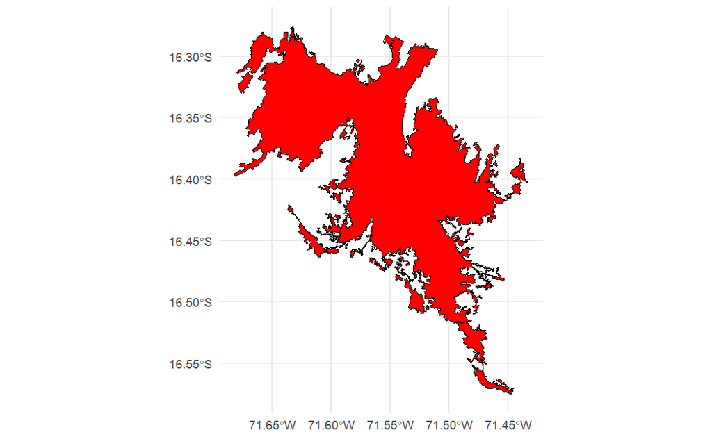

```r
arequipa <- continuos_poblados_full[continuos_poblados_full$objectid == 1175, ]

ggplot() +
  geom_sf(data = arequipa, fill = "red", color = "black") +
  theme_minimal()
```

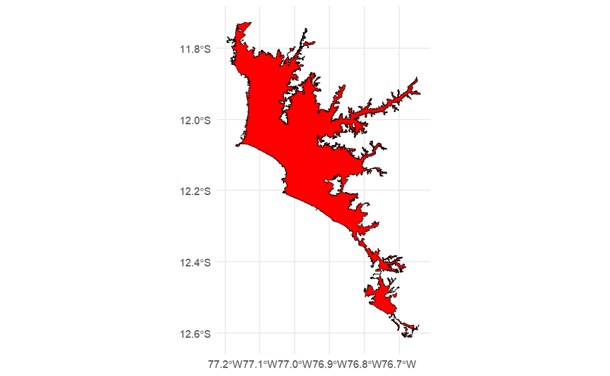

```r
lima <- continuos_poblados_full[continuos_poblados_full$objectid == 1163, ]

ggplot() +
  geom_sf(data = lima, fill = "red", color = "black") +
  theme_minimal()
```

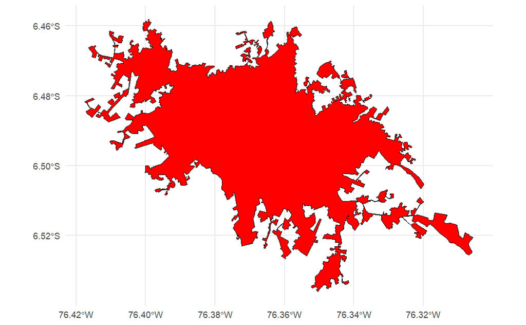

```r
tarapoto <- continuos_poblados_full[continuos_poblados_full$objectid == 1075, ]

ggplot() +
  geom_sf(data = tarapoto, fill = "red", color = "black") +
  theme_minimal()
```

Ahora que vemos que ha funcionado, exportamos la base de datos en dos formatos.

RDS

```r
saveRDS(continuos_poblados_full, "continuos_poblados_SICCEP.rds")
```

GeoPackage (gpkg)

```r
st_write(continuos_poblados_full, "continuos_poblados_SICCEP.gpkg", delete_dsn = TRUE)
```